# S_van_Mesdag_T_tests_and_Wilcoxon_tests

Savanna van Mesdag

2023-09-16

```r
#To install the packages prior to analysis

library(tidyverse)
library(rstatix)
#Loading the packages prior to analyses

library(tidyverse)
library(rstatix)
library(ggpubr)
#Loading the data

urlfile1 <- 'https://raw.githubusercontent.com/Savannankvm/T-tests-and-Wilcoxon-rank-sum-tests-Barrow/PhD-files/Capped_and_uncapped_Barrow_1.csv'

Barrow_Capped_Uncapped <- read.csv("Capped_and_uncapped_Barrow_1.csv")
print(Barrow_Capped_Uncapped)
```

```
##    Technique     pH SiO2 Al2O3 Fe2O3   CaO  MgO Na2O  K2O Cr2O3 TiO2  MnO P2O5
## 1   Uncapped  9.921 30.7  8.99  1.20 35.70 3.07 0.58 0.43 0.003 0.49 0.58 0.06
## 2     Capped  8.850 47.3 10.05  3.99 13.30 1.36 0.73 1.90 0.014 0.59 0.16 0.14
## 3     Capped  7.701 46.2 16.75  7.65  4.88 1.32 1.12 2.79 0.028 1.34 0.35 0.37
## 4     Capped  8.295 55.8  8.18  3.20 11.15 1.10 0.80 1.74 0.011 0.51 0.08 0.14
## 5   Uncapped  8.363 40.3 12.05  3.63 20.60 1.18 0.39 0.99 0.011 0.48 0.38 0.15
## 6     Capped  8.047 60.8  9.78  4.50  4.32 1.50 0.89 2.00 0.015 0.51 0.16 0.16
## 7     Capped  9.841 56.9  9.89  4.22  8.03 1.62 0.88 1.97 0.015 0.51 0.16 0.13
## 8     Capped 10.294 52.8 10.20  3.62 12.00 1.44 0.72 1.74 0.012 0.49 0.18 0.11
## 9   Uncapped 10.797 19.8  4.87  0.63 44.30 1.09 0.19 0.33 0.003 0.12 0.21 0.02
## 10    Capped  9.019 53.9  8.39  3.87 12.25 1.80 0.77 1.48 0.012 0.49 0.34 0.11
## 11  Uncapped 10.774 27.7  7.13  1.04 39.00 1.86 0.23 0.37 0.002 0.16 0.25 0.01
##     SrO  BaO    Ag     As     B      Be    Bi      Cd     Co     Cu    Ga    Hg
## 1  0.08 0.34 2e-05 0.0005 0.003 0.00103 2e-04 0.00005 0.0002 0.0028 0.001 1e-04
## 2  0.02 0.07 2e-05 0.0015 0.002 0.00021 2e-04 0.00005 0.0011 0.0044 0.001 1e-04
```

[output cut: 57 more lines]

```r
Barrow_Capped_Uncapped_na <- na.omit(Barrow_Capped_Uncapped)
```

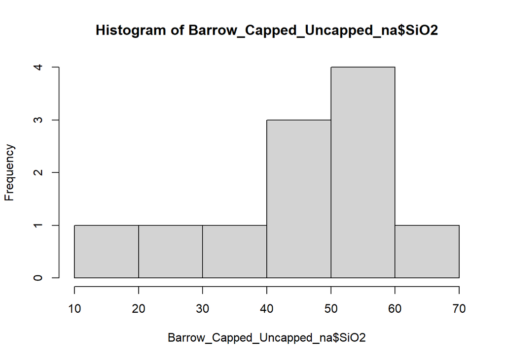

```r
hist(Barrow_Capped_Uncapped_na$SiO2)
```

#From this histogram, it can be seen that SiO2 has a non-normal distribution. Therefore, #a Wilcoxon test, rather than a t test, will be carried out for SiO2 in the uncapped and #capped substrates.

```r
SiO2Wilcox <- wilcox.test(Barrow_Capped_Uncapped_na[,3] ~ Barrow_Capped_Uncapped_na[,1])
print(SiO2Wilcox)
```

```
##
##  Wilcoxon rank sum exact test
##
## data:  Barrow_Capped_Uncapped_na[, 3] by Barrow_Capped_Uncapped_na[, 1]
## W = 28, p-value = 0.006061
## alternative hypothesis: true location shift is not equal to 0
```

#A quick t-test for the data just to obtain the means more quickly and efficiently…

```r
Capping_t_test_SiO2 <- t.test(Barrow_Capped_Uncapped_na[,3] ~ Barrow_Capped_Uncapped_na[,1])

print(Capping_t_test_SiO2)
```

```
##
##  Welch Two Sample t-test
##
## data:  Barrow_Capped_Uncapped_na[, 3] by Barrow_Capped_Uncapped_na[, 1]
## t = 5.0875, df = 4.3318, p-value = 0.00568
## alternative hypothesis: true difference in means between group Capped and group Uncapped is not equal to 0
## 95 percent confidence interval:
##  11.17594 36.34549
## sample estimates:
##   mean in group Capped mean in group Uncapped
##               53.38571               29.62500
```

#The Wilcoxon test demonstrates that there are significant differences between SiO2 on #capped and uncapped parts of the slag bank. SiO2 was recorded in significantly higher #levels on capped substrates on-site.

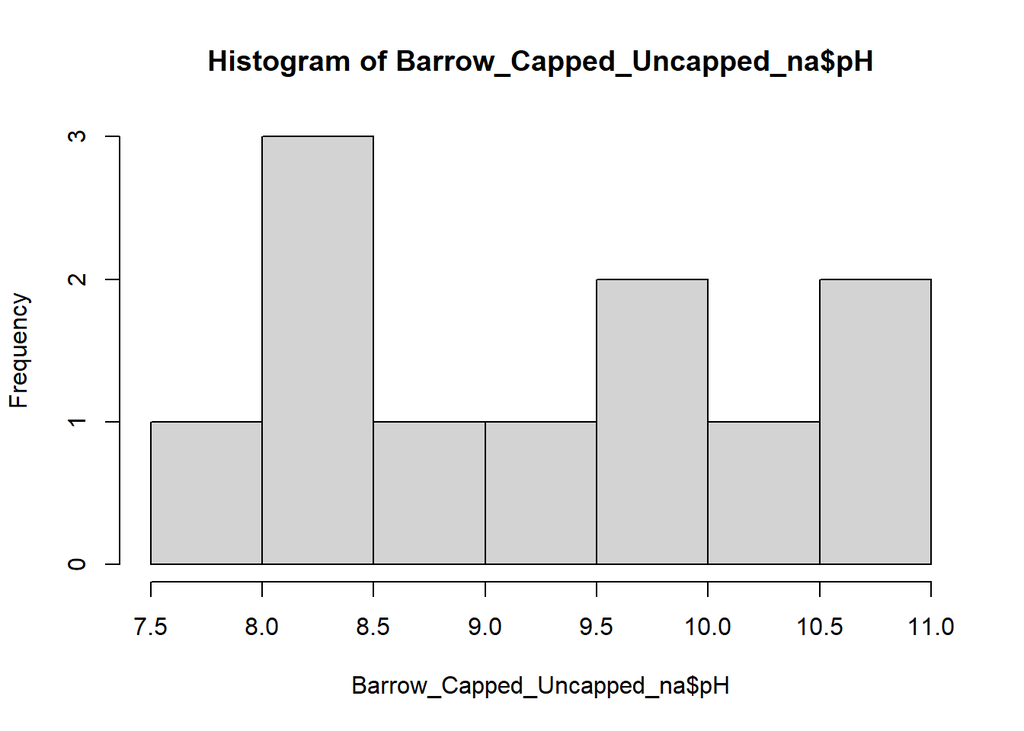

```r
hist(Barrow_Capped_Uncapped_na$pH)
```

#Non-normal distribution, will do a Wilcoxon rank sum test…

```r
pHWilcox <- wilcox.test(Barrow_Capped_Uncapped_na[,2] ~ Barrow_Capped_Uncapped_na[,1])
print(pHWilcox)
```

```
##
##  Wilcoxon rank sum exact test
##
## data:  Barrow_Capped_Uncapped_na[, 2] by Barrow_Capped_Uncapped_na[, 1]
## W = 5, p-value = 0.1091
## alternative hypothesis: true location shift is not equal to 0
```

#No significant differences

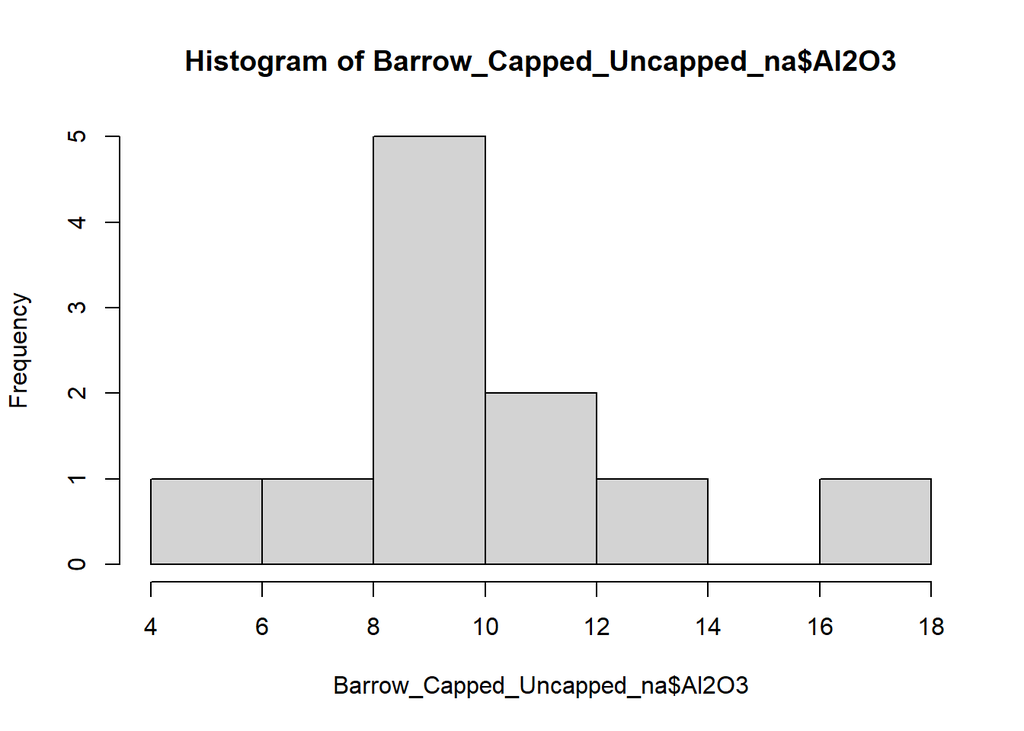

```r
hist(Barrow_Capped_Uncapped_na$Al2O3)
```

#Will do a Wilcoxon test for Al2O3 as well, non-normal distribution.

```r
Al2O3Wilcox <-wilcox.test(Barrow_Capped_Uncapped_na[,4] ~ Barrow_Capped_Uncapped_na[,1])

print(Al2O3Wilcox)
```

```
##
##  Wilcoxon rank sum exact test
##
## data:  Barrow_Capped_Uncapped_na[, 4] by Barrow_Capped_Uncapped_na[, 1]
## W = 20, p-value = 0.3152
## alternative hypothesis: true location shift is not equal to 0
```

#No significant differences

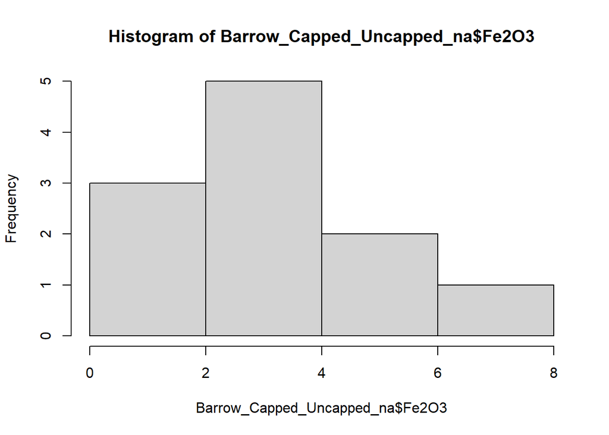

```r
hist(Barrow_Capped_Uncapped_na$Fe2O3)
```

#Will do a Wilcoxon test for Fe2O3, non-normal distribution.

```r
Fe2O3Wilcox <-wilcox.test(Barrow_Capped_Uncapped_na[,5] ~ Barrow_Capped_Uncapped_na[,1])
print(Fe2O3Wilcox)
```

```
##
##  Wilcoxon rank sum exact test
##
## data:  Barrow_Capped_Uncapped_na[, 5] by Barrow_Capped_Uncapped_na[, 1]
## W = 26, p-value = 0.02424
## alternative hypothesis: true location shift is not equal to 0
```

#A quick t-test for the data just to obtain the means more quickly and efficiently…

```r
Capping_t_test_Fe2O3 <- t.test(Barrow_Capped_Uncapped_na[,5] ~ Barrow_Capped_Uncapped_na[,1])

print(Capping_t_test_Fe2O3)
```

```
##
##  Welch Two Sample t-test
##
## data:  Barrow_Capped_Uncapped_na[, 5] by Barrow_Capped_Uncapped_na[, 1]
## t = 3.1973, df = 6.8602, p-value = 0.01554
## alternative hypothesis: true difference in means between group Capped and group Uncapped is not equal to 0
## 95 percent confidence interval:
##  0.7233459 4.8980827
## sample estimates:
##   mean in group Capped mean in group Uncapped
##               4.435714               1.625000
```

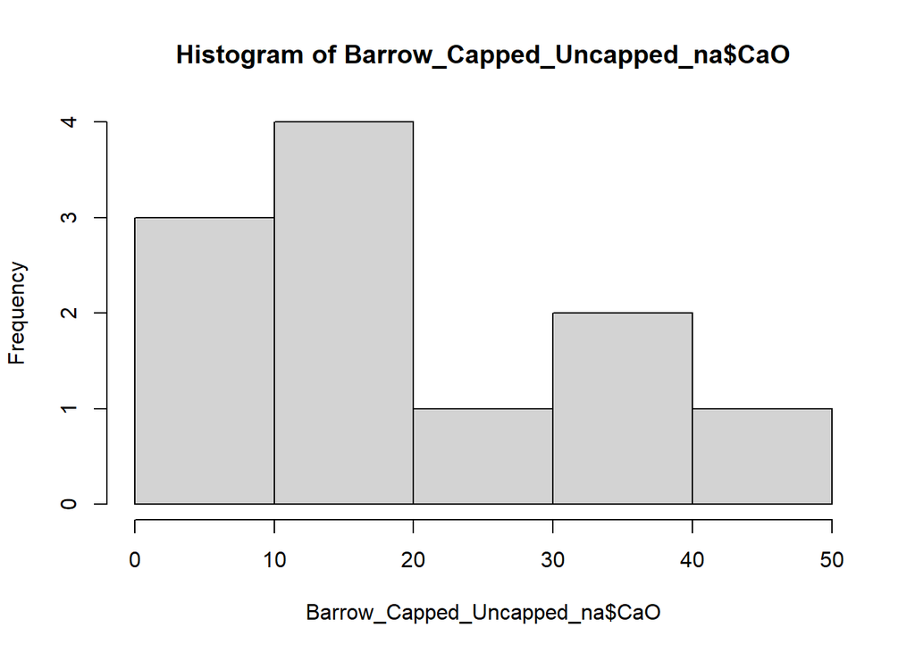

```r
hist(Barrow_Capped_Uncapped_na$CaO)
```

#Again, a non-normal distribution, so time for another Wilcoxon rank sum test…

```r
CaOWilcox <-wilcox.test(Barrow_Capped_Uncapped_na[,6] ~ Barrow_Capped_Uncapped_na[,1])
print(CaOWilcox)
```

```
##
##  Wilcoxon rank sum exact test
##
## data:  Barrow_Capped_Uncapped_na[, 6] by Barrow_Capped_Uncapped_na[, 1]
## W = 0, p-value = 0.006061
## alternative hypothesis: true location shift is not equal to 0
```

```r
#A quick t-test for the data just to obtain the means...

Capping_t_test_CaO <- t.test(Barrow_Capped_Uncapped_na[,6] ~ Barrow_Capped_Uncapped_na[,1])

print(Capping_t_test_CaO)
```

```
##
##  Welch Two Sample t-test
##
## data:  Barrow_Capped_Uncapped_na[, 6] by Barrow_Capped_Uncapped_na[, 1]
## t = -4.8334, df = 3.4561, p-value = 0.0121
## alternative hypothesis: true difference in means between group Capped and group Uncapped is not equal to 0
## 95 percent confidence interval:
##  -41.073475  -9.889382
## sample estimates:
##   mean in group Capped mean in group Uncapped
##               9.418571              34.900000
```

#The Wilcoxon test demonstrates that there are significant differences between CaO on #capped and uncapped parts of the slag bank. CaO was recorded in significantly higher #levels on uncapped substrates on-site.

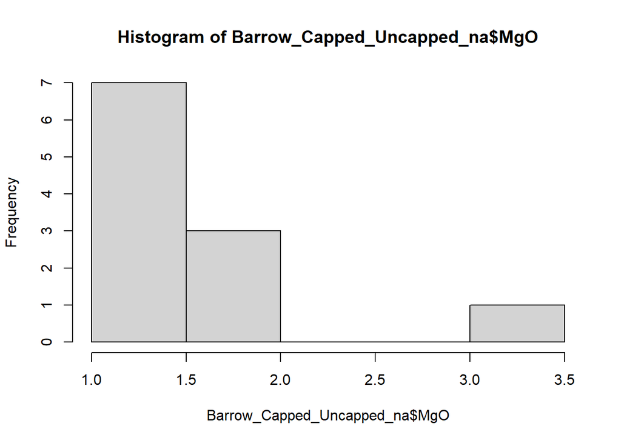

```r
hist(Barrow_Capped_Uncapped_na$MgO)
```

#Again, a non-normal distribution, so time for another Wilcoxon rank sum test…

```r
MgOWilcox <-wilcox.test(Barrow_Capped_Uncapped_na[,7] ~ Barrow_Capped_Uncapped_na[,1])
print(MgOWilcox)
```

```
##
##  Wilcoxon rank sum exact test
##
## data:  Barrow_Capped_Uncapped_na[, 7] by Barrow_Capped_Uncapped_na[, 1]
## W = 13, p-value = 0.9273
## alternative hypothesis: true location shift is not equal to 0
```

#No significant differences.

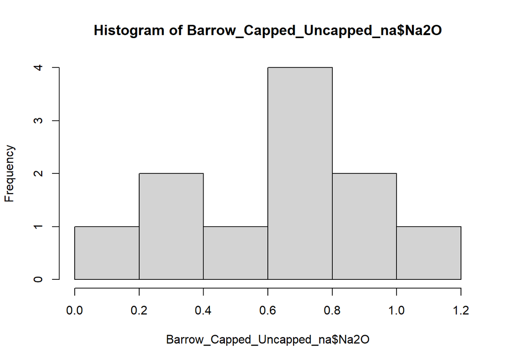

```r
hist(Barrow_Capped_Uncapped_na$Na2O)
```

#This shows more of a normal distribution, so a t-test can be done for this one.

```r
Capping_t_test_Na2O <- t.test(Barrow_Capped_Uncapped_na[,8] ~ Barrow_Capped_Uncapped_na[,1])
print(Capping_t_test_Na2O)
```

```
##
##  Welch Two Sample t-test
##
## data:  Barrow_Capped_Uncapped_na[, 8] by Barrow_Capped_Uncapped_na[, 1]
## t = 4.8207, df = 5.1455, p-value = 0.004445
## alternative hypothesis: true difference in means between group Capped and group Uncapped is not equal to 0
## 95 percent confidence interval:
##  0.2341172 0.7594542
## sample estimates:
##   mean in group Capped mean in group Uncapped
##              0.8442857              0.3475000
```

#From the t-test, it can be seen that Na2O is significantly lower in uncapped than #capped substrates on the Barrow slag bank.

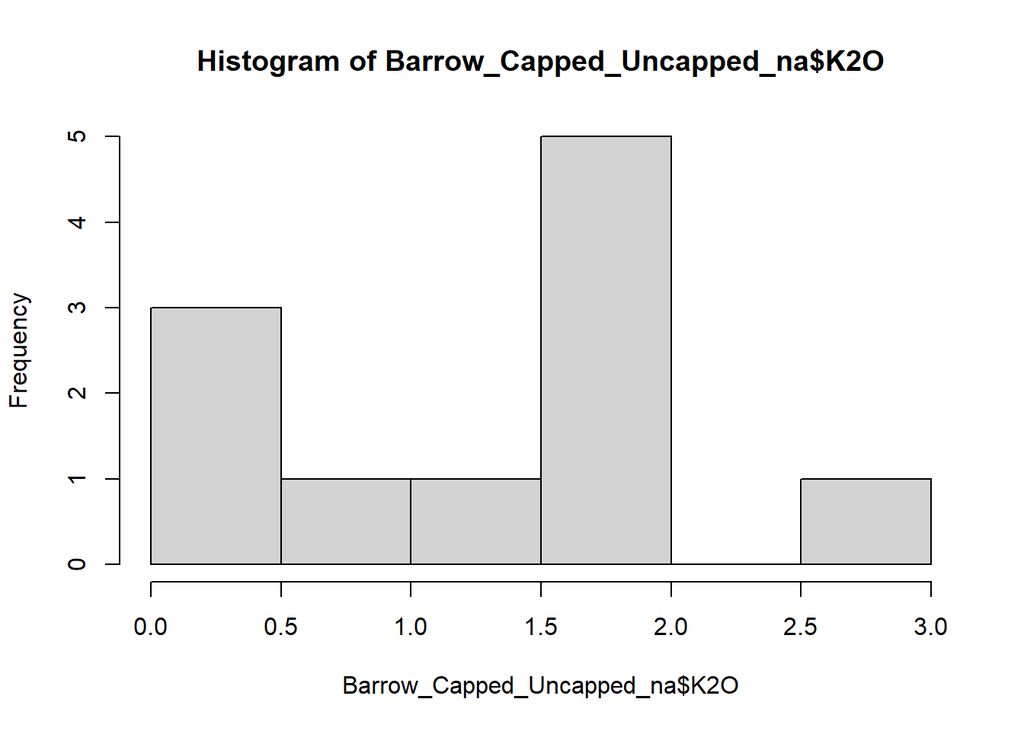

```r
hist(Barrow_Capped_Uncapped_na$K2O)
```

#Another non-normal distribution, so will do another Wilcoxon rank sum test.

```r
K2OWilcox <-wilcox.test(Barrow_Capped_Uncapped_na[,9] ~ Barrow_Capped_Uncapped_na[,1])
print(K2OWilcox)
```

```
##
##  Wilcoxon rank sum test with continuity correction
##
## data:  Barrow_Capped_Uncapped_na[, 9] by Barrow_Capped_Uncapped_na[, 1]
## W = 28, p-value = 0.01056
## alternative hypothesis: true location shift is not equal to 0
```

#A quick t-test for the data just to obtain the means…

```r
Capping_t_test_K2O <- t.test(Barrow_Capped_Uncapped_na[,9] ~ Barrow_Capped_Uncapped_na[,1])
print(Capping_t_test_K2O)
```

```
##
##  Welch Two Sample t-test
##
## data:  Barrow_Capped_Uncapped_na[, 9] by Barrow_Capped_Uncapped_na[, 1]
## t = 6.4472, df = 8.0387, p-value = 0.0001948
## alternative hypothesis: true difference in means between group Capped and group Uncapped is not equal to 0
## 95 percent confidence interval:
##  0.9097698 1.9216588
## sample estimates:
##   mean in group Capped mean in group Uncapped
##               1.945714               0.530000
```

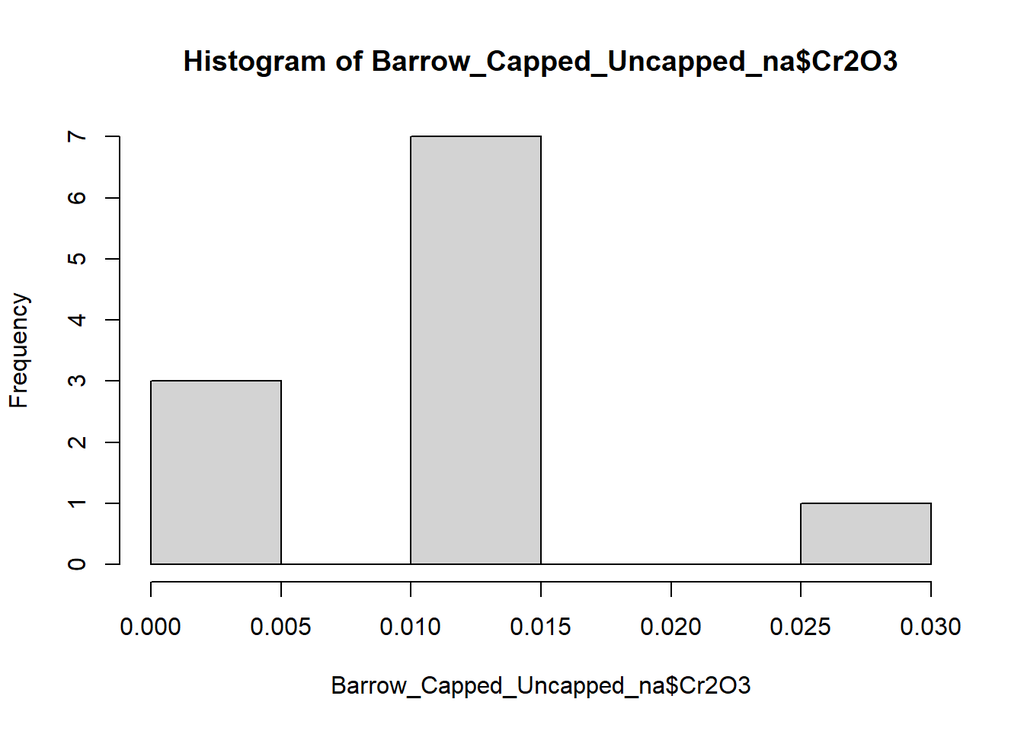

```r
hist(Barrow_Capped_Uncapped_na$Cr2O3)
```

#Non-normal distribution.

```r
Cr2O3Wilcox <-wilcox.test(Barrow_Capped_Uncapped_na[,10] ~ Barrow_Capped_Uncapped_na[,1])
print(Cr2O3Wilcox)
```

```
##
##  Wilcoxon rank sum test with continuity correction
##
## data:  Barrow_Capped_Uncapped_na[, 10] by Barrow_Capped_Uncapped_na[, 1]
## W = 27.5, p-value = 0.01316
## alternative hypothesis: true location shift is not equal to 0
```

#A quick t-test for the data just to obtain the means…

```r
Capping_t_test_Cr2O3 <- t.test(Barrow_Capped_Uncapped_na[,10] ~ Barrow_Capped_Uncapped_na[,1])
print(Capping_t_test_Cr2O3)
```

```
##
##  Welch Two Sample t-test
##
## data:  Barrow_Capped_Uncapped_na[, 10] by Barrow_Capped_Uncapped_na[, 1]
## t = 3.4661, df = 8.247, p-value = 0.008102
## alternative hypothesis: true difference in means between group Capped and group Uncapped is not equal to 0
## 95 percent confidence interval:
##  0.003562688 0.017508740
## sample estimates:
##   mean in group Capped mean in group Uncapped
##             0.01528571             0.00475000
```

#Cr2O3 levels are significantly higher in capped substrates on the Barrow slag bank.

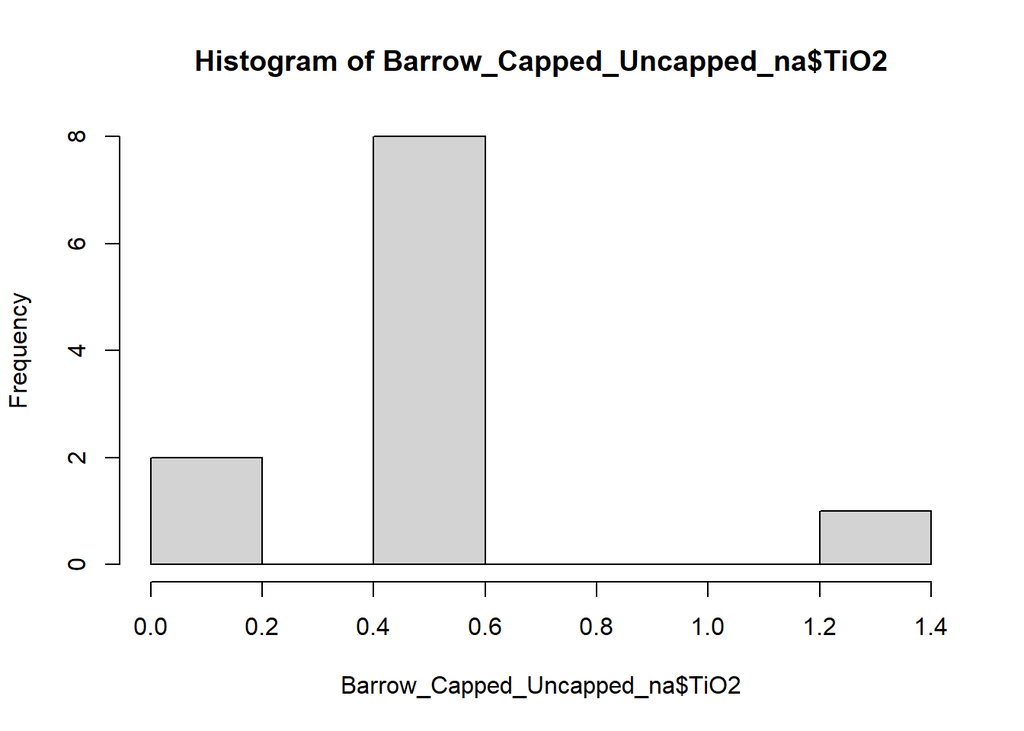

```r
hist(Barrow_Capped_Uncapped_na$TiO2)
```

#Non-normal distribution

```r
TiO2Wilcox <-wilcox.test(Barrow_Capped_Uncapped_na[,11] ~ Barrow_Capped_Uncapped_na[,1])
print(TiO2Wilcox)
```

```
##
##  Wilcoxon rank sum test with continuity correction
##
## data:  Barrow_Capped_Uncapped_na[, 11] by Barrow_Capped_Uncapped_na[, 1]
## W = 27, p-value = 0.01611
## alternative hypothesis: true location shift is not equal to 0
```

#T-test for means…

```r
Capping_t_test_TiO2 <- t.test(Barrow_Capped_Uncapped_na[,11] ~Barrow_Capped_Uncapped_na[,1])
print(Capping_t_test_TiO2)
```

```
##
##  Welch Two Sample t-test
##
## data:  Barrow_Capped_Uncapped_na[, 11] by Barrow_Capped_Uncapped_na[, 1]
## t = 2.0776, df = 8.7288, p-value = 0.06848
## alternative hypothesis: true difference in means between group Capped and group Uncapped is not equal to 0
## 95 percent confidence interval:
##  -0.03025155  0.67382298
## sample estimates:
##   mean in group Capped mean in group Uncapped
##              0.6342857              0.3125000
```

#TiO2 levels are significantly higher in capped substrates on the Barrow slag bank.

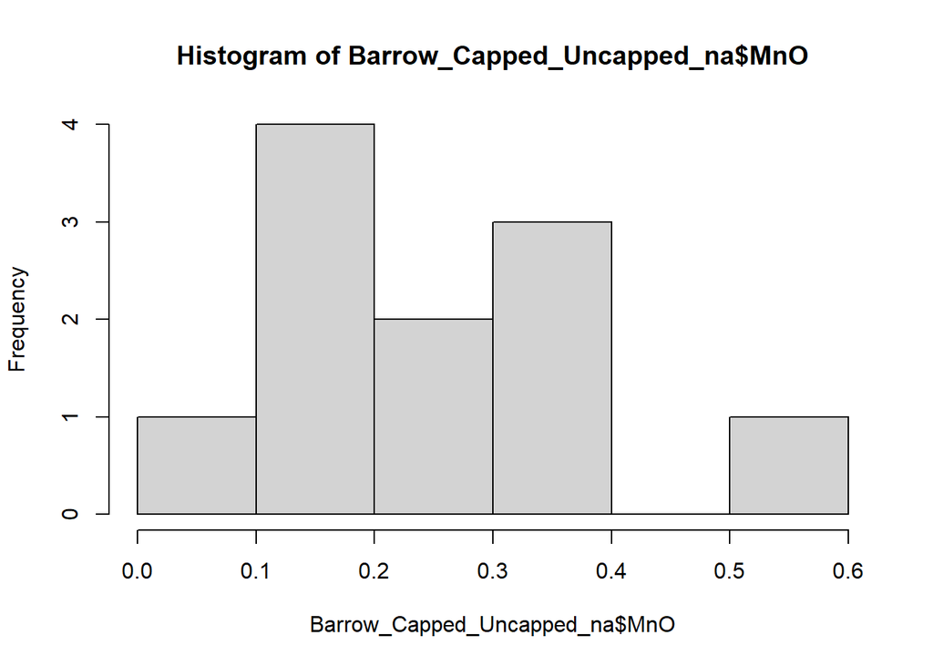

```r
hist(Barrow_Capped_Uncapped_na$MnO)
```

#Non-normal distribution

```r
MnOWilcox <-wilcox.test(Barrow_Capped_Uncapped_na[,12] ~ Barrow_Capped_Uncapped_na[,1])
print(MnOWilcox)
```

```
##
##  Wilcoxon rank sum test with continuity correction
##
## data:  Barrow_Capped_Uncapped_na[, 12] by Barrow_Capped_Uncapped_na[, 1]
## W = 4, p-value = 0.07
## alternative hypothesis: true location shift is not equal to 0
```

#No significant differences.

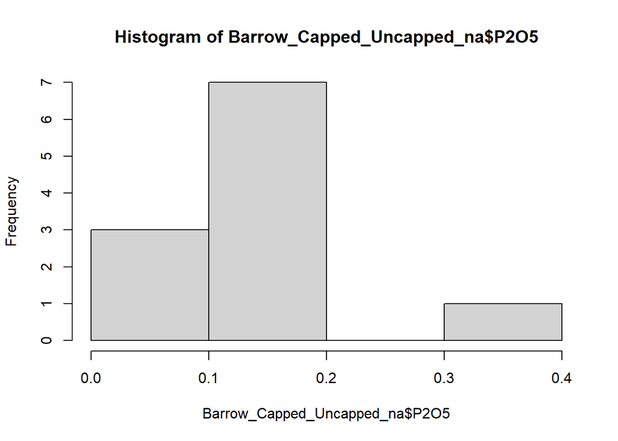

```r
hist(Barrow_Capped_Uncapped_na$P2O5)
```

#Non-normal distribution

```r
P2O5Wilcox <-wilcox.test(Barrow_Capped_Uncapped_na[,13] ~ Barrow_Capped_Uncapped_na[,1])
print(P2O5Wilcox)
```

```
##
##  Wilcoxon rank sum test with continuity correction
##
## data:  Barrow_Capped_Uncapped_na[, 13] by Barrow_Capped_Uncapped_na[, 1]
## W = 23, p-value = 0.1066
## alternative hypothesis: true location shift is not equal to 0
```

#No significant differences

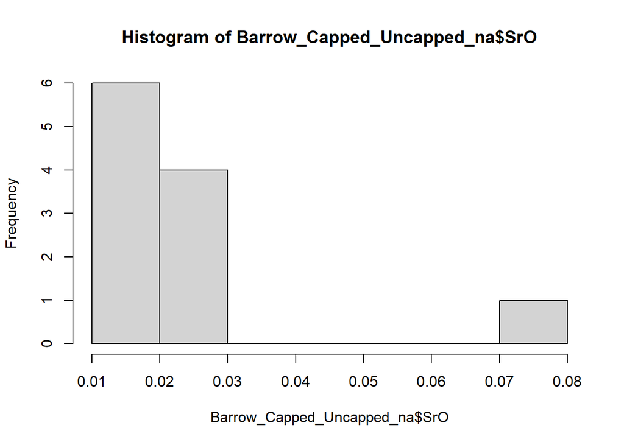

```r
hist(Barrow_Capped_Uncapped_na$SrO)
```

#Non-normal distribution

```r
SrOWilcox <-wilcox.test(Barrow_Capped_Uncapped_na[,14] ~ Barrow_Capped_Uncapped_na[,1])
print(SrOWilcox)
```

```
##
##  Wilcoxon rank sum test with continuity correction
##
## data:  Barrow_Capped_Uncapped_na[, 14] by Barrow_Capped_Uncapped_na[, 1]
## W = 1.5, p-value = 0.01468
## alternative hypothesis: true location shift is not equal to 0
```

#T-test for means…

```r
Capping_t_test_SrO <- t.test(Barrow_Capped_Uncapped_na[,14] ~ Barrow_Capped_Uncapped_na[,1])
print(Capping_t_test_SrO)
```

```
##
##  Welch Two Sample t-test
##
## data:  Barrow_Capped_Uncapped_na[, 14] by Barrow_Capped_Uncapped_na[, 1]
## t = -2.1959, df = 3.3438, p-value = 0.1064
## alternative hypothesis: true difference in means between group Capped and group Uncapped is not equal to 0
## 95 percent confidence interval:
##  -0.06682632  0.01039775
## sample estimates:
##   mean in group Capped mean in group Uncapped
##             0.01428571             0.04250000
```

#SrO levels are significantly higher in uncapped substrates on the Barrow slag bank.

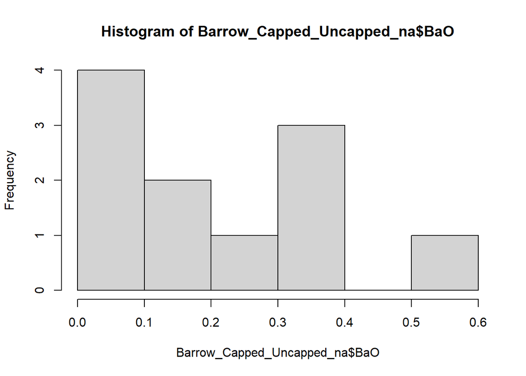

```r
hist(Barrow_Capped_Uncapped_na$BaO)
```

#Non-normal distribution

```r
BaOWilcox <-wilcox.test(Barrow_Capped_Uncapped_na[,15] ~ Barrow_Capped_Uncapped_na[,1])
print(BaOWilcox)
```

```
##
##  Wilcoxon rank sum test with continuity correction
##
## data:  Barrow_Capped_Uncapped_na[, 15] by Barrow_Capped_Uncapped_na[, 1]
## W = 0, p-value = 0.01056
## alternative hypothesis: true location shift is not equal to 0
```

#T-test for means…

```r
Capping_t_test_BaO <- t.test(Barrow_Capped_Uncapped_na[,15] ~ Barrow_Capped_Uncapped_na[,1])
print(Capping_t_test_BaO)
```

```
##
##  Welch Two Sample t-test
##
## data:  Barrow_Capped_Uncapped_na[, 15] by Barrow_Capped_Uncapped_na[, 1]
## t = -4.5914, df = 4.0428, p-value = 0.009846
## alternative hypothesis: true difference in means between group Capped and group Uncapped is not equal to 0
## 95 percent confidence interval:
##  -0.4732207 -0.1174936
## sample estimates:
##   mean in group Capped mean in group Uncapped
##              0.1071429              0.4025000
```

#BaO levels are significantly higher in uncapped parts of the Barrow slag bank.

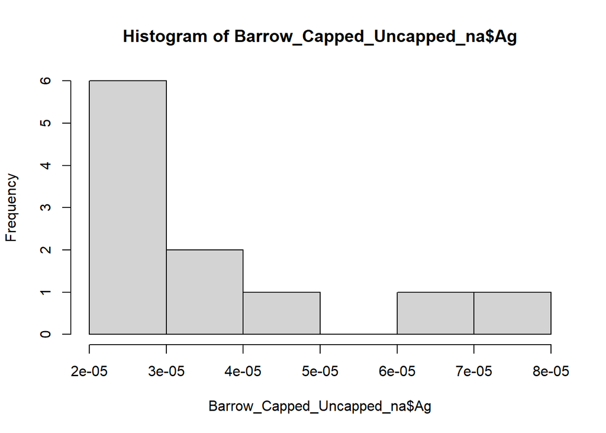

```r
hist(Barrow_Capped_Uncapped_na$Ag)
```

#Non-normal distribution

```r
AgWilcox <-wilcox.test(Barrow_Capped_Uncapped_na[,16] ~ Barrow_Capped_Uncapped_na[,1])
print(AgWilcox)
```

```
##
##  Wilcoxon rank sum test with continuity correction
##
## data:  Barrow_Capped_Uncapped_na[, 16] by Barrow_Capped_Uncapped_na[, 1]
## W = 15.5, p-value = 0.8459
## alternative hypothesis: true location shift is not equal to 0
```

#No significant differences

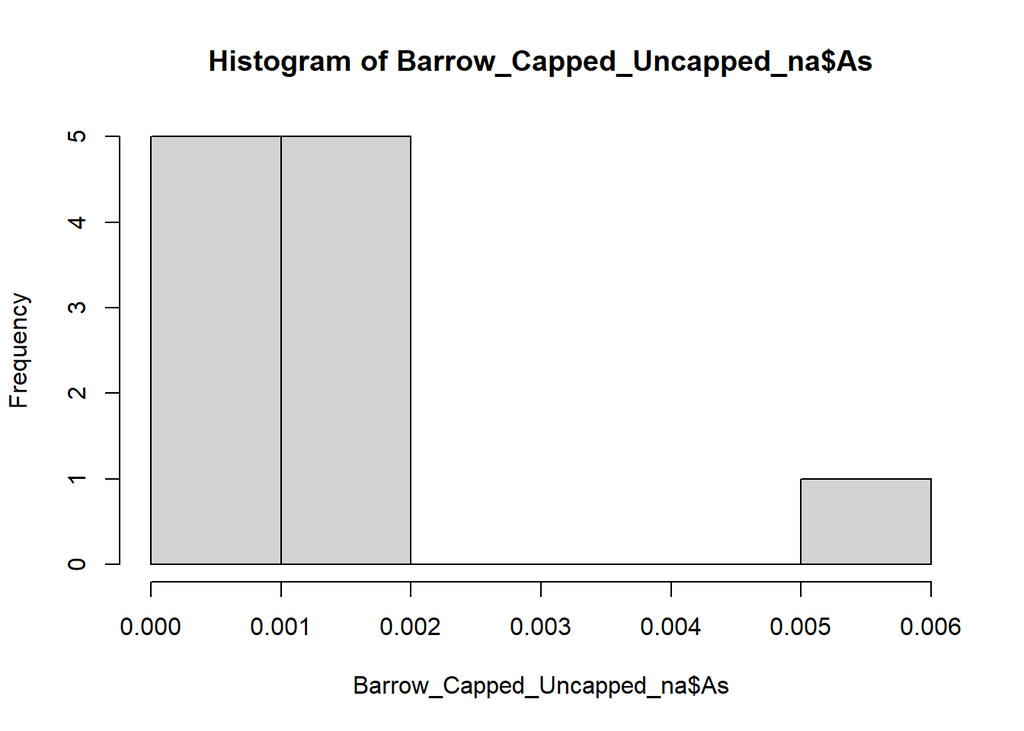

```r
hist(Barrow_Capped_Uncapped_na$As)
```

#Non-normal distribution

```r
AsWilcox <-wilcox.test(Barrow_Capped_Uncapped_na[,17] ~ Barrow_Capped_Uncapped_na[,1])
print(AsWilcox)
```

```
##
##  Wilcoxon rank sum test with continuity correction
##
## data:  Barrow_Capped_Uncapped_na[, 17] by Barrow_Capped_Uncapped_na[, 1]
## W = 28, p-value = 0.0102
## alternative hypothesis: true location shift is not equal to 0
```

#T-test for means.

```r
Capping_t_test_As <- t.test(Barrow_Capped_Uncapped_na[,17] ~ Barrow_Capped_Uncapped_na[,1])
print(Capping_t_test_As)
```

```
##
##  Welch Two Sample t-test
##
## data:  Barrow_Capped_Uncapped_na[, 17] by Barrow_Capped_Uncapped_na[, 1]
## t = 2.0043, df = 6.1917, p-value = 0.0904
## alternative hypothesis: true difference in means between group Capped and group Uncapped is not equal to 0
## 95 percent confidence interval:
##  -0.0002918837  0.0030490266
## sample estimates:
##   mean in group Capped mean in group Uncapped
##            0.001928571            0.000550000
```

#Significantly higher levels of As on capped substrates on the Barrow slag bank.

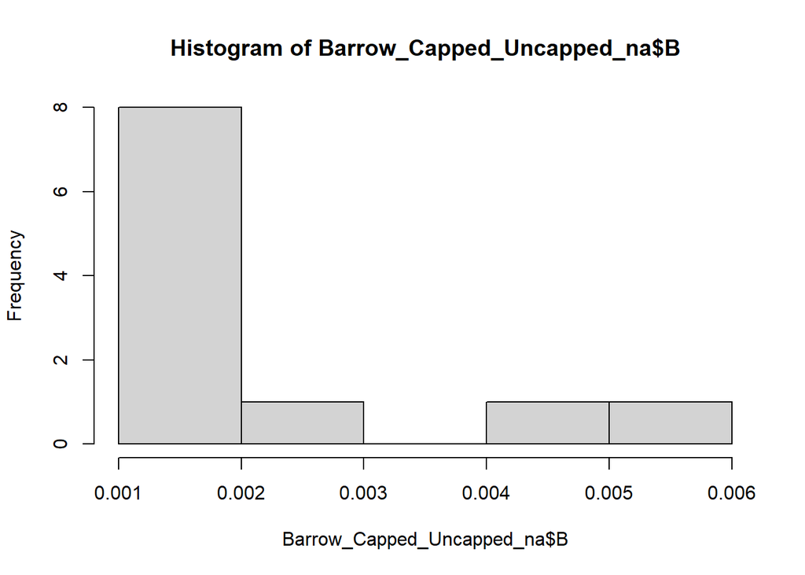

```r
hist(Barrow_Capped_Uncapped_na$B)
```

#Non-normal distribution.

```r
BWilcoxB <-wilcox.test(Barrow_Capped_Uncapped_na[,18] ~ Barrow_Capped_Uncapped_na[,1])
print(BWilcoxB)
```

```
##
##  Wilcoxon rank sum test with continuity correction
##
## data:  Barrow_Capped_Uncapped_na[, 18] by Barrow_Capped_Uncapped_na[, 1]
## W = 2, p-value = 0.02131
## alternative hypothesis: true location shift is not equal to 0
```

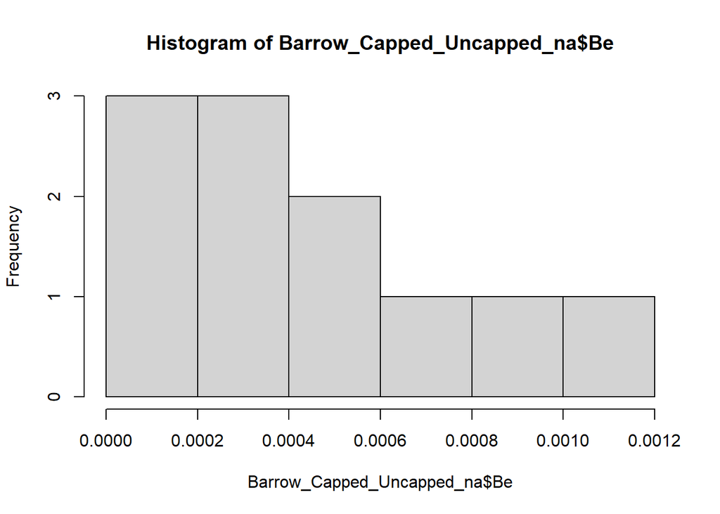

```r
hist(Barrow_Capped_Uncapped_na$Be)
```

#Non-normal distribution

```r
BeWilcox <-wilcox.test(Barrow_Capped_Uncapped_na[,19] ~ Barrow_Capped_Uncapped_na[,1])
print(BeWilcox)
```

```
##
##  Wilcoxon rank sum exact test
##
## data:  Barrow_Capped_Uncapped_na[, 19] by Barrow_Capped_Uncapped_na[, 1]
## W = 0, p-value = 0.006061
## alternative hypothesis: true location shift is not equal to 0
```

#T-test for means

```r
Capping_t_test_Be <- t.test(Barrow_Capped_Uncapped_na[,19] ~ Barrow_Capped_Uncapped_na[,1])
print(Capping_t_test_Be)
```

```
##
##  Welch Two Sample t-test
##
## data:  Barrow_Capped_Uncapped_na[, 19] by Barrow_Capped_Uncapped_na[, 1]
## t = -4.7466, df = 4.2643, p-value = 0.007675
## alternative hypothesis: true difference in means between group Capped and group Uncapped is not equal to 0
## 95 percent confidence interval:
##  -0.0008892461 -0.0002428967
## sample estimates:
##   mean in group Capped mean in group Uncapped
##           0.0002214286           0.0007875000
```

#Be levels are significantly higher in uncapped substrates on the Barrow slag bank.

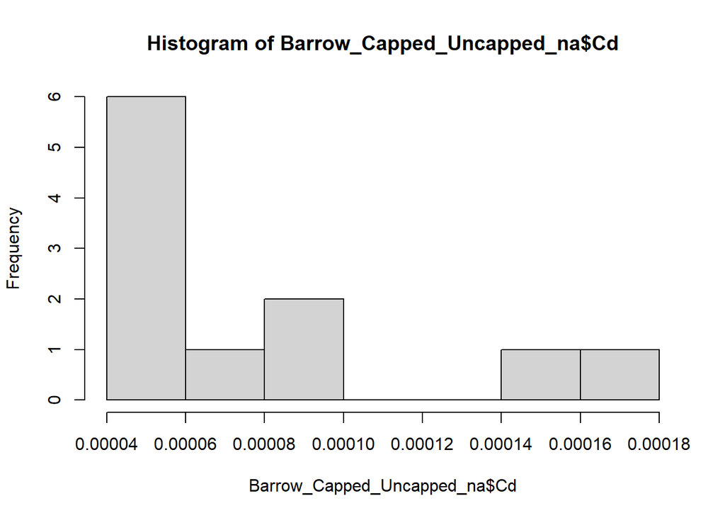

```r
hist(Barrow_Capped_Uncapped_na$Cd)
```

#Non-normal distribution

```r
CdWilcox <-wilcox.test(Barrow_Capped_Uncapped_na[,21] ~ Barrow_Capped_Uncapped_na[,1])
print(CdWilcox)
```

```
##
##  Wilcoxon rank sum test with continuity correction
##
## data:  Barrow_Capped_Uncapped_na[, 21] by Barrow_Capped_Uncapped_na[, 1]
## W = 18.5, p-value = 0.4097
## alternative hypothesis: true location shift is not equal to 0
```

#No significant differences

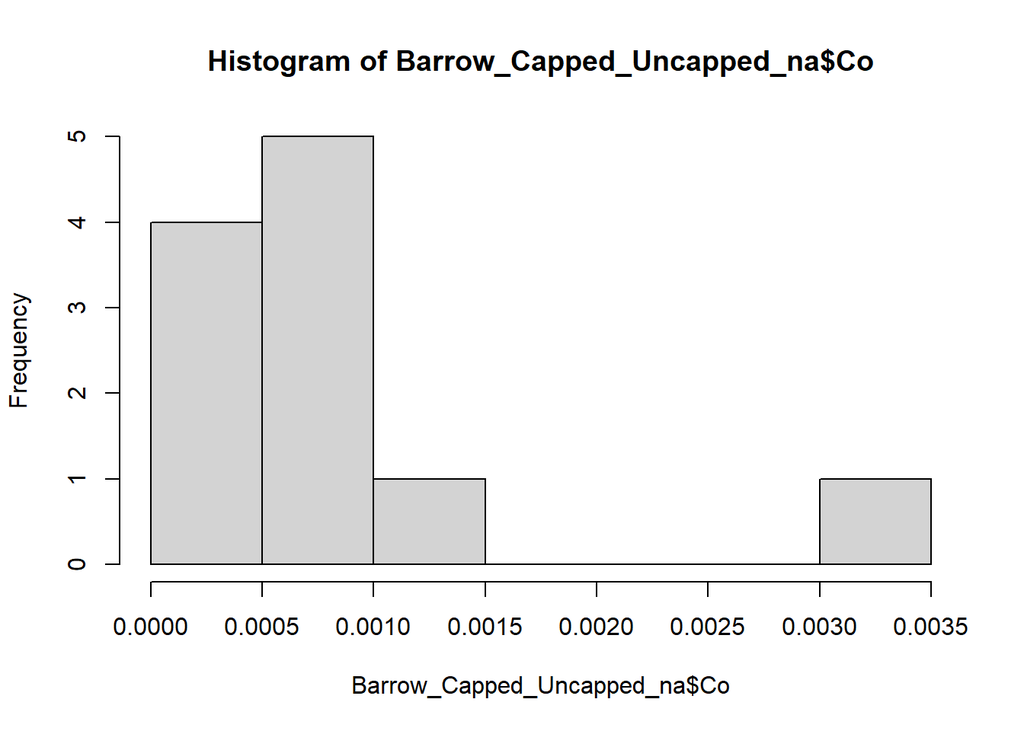

```r
hist(Barrow_Capped_Uncapped_na$Co)
```

#Non-normal distribution

```r
CoWilcox <-wilcox.test(Barrow_Capped_Uncapped_na[,22] ~ Barrow_Capped_Uncapped_na[,1])
print(CoWilcox)
```

```
##
##  Wilcoxon rank sum test with continuity correction
##
## data:  Barrow_Capped_Uncapped_na[, 22] by Barrow_Capped_Uncapped_na[, 1]
## W = 28, p-value = 0.0102
## alternative hypothesis: true location shift is not equal to 0
```

#T-test for means.

```r
Capping_t_test_Co <- t.test(Barrow_Capped_Uncapped_na[,22] ~ Barrow_Capped_Uncapped_na[,1])
print(Capping_t_test_Co)
```

```
##
##  Welch Two Sample t-test
##
## data:  Barrow_Capped_Uncapped_na[, 22] by Barrow_Capped_Uncapped_na[, 1]
## t = 2.7141, df = 6.4214, p-value = 0.03264
## alternative hypothesis: true difference in means between group Capped and group Uncapped is not equal to 0
## 95 percent confidence interval:
##  0.0001033453 0.0017323690
## sample estimates:
##   mean in group Capped mean in group Uncapped
##            0.001142857            0.000225000
```

#Co levels are significantly higher in capped substrates on the Barrow slag bank.

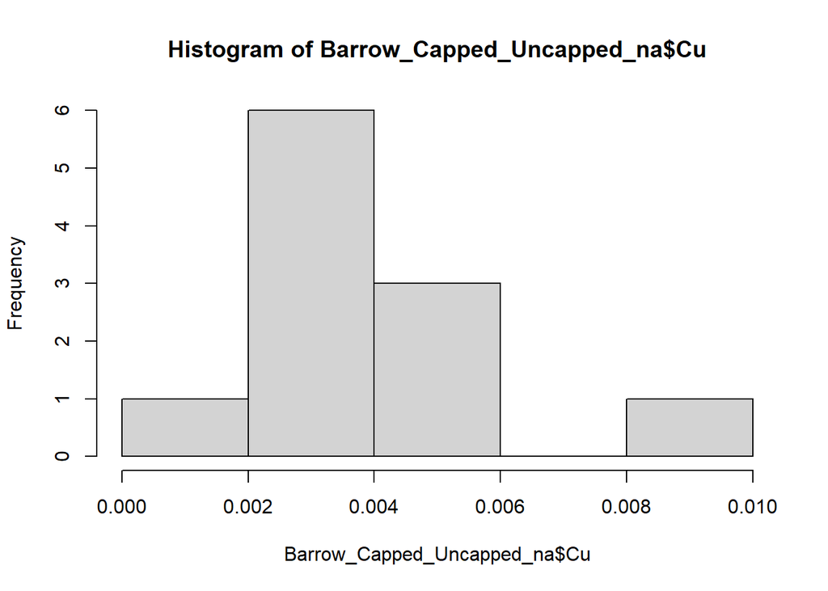

```r
hist(Barrow_Capped_Uncapped_na$Cu)
```

#Non-normal distribution

```r
CuWilcox <-wilcox.test(Barrow_Capped_Uncapped_na[,23] ~ Barrow_Capped_Uncapped_na[,1])
print(CuWilcox)
```

```
##
##  Wilcoxon rank sum test with continuity correction
##
## data:  Barrow_Capped_Uncapped_na[, 23] by Barrow_Capped_Uncapped_na[, 1]
## W = 27.5, p-value = 0.0138
## alternative hypothesis: true location shift is not equal to 0
```

#T test for means…

```r
Capping_t_test_Cu <- t.test(Barrow_Capped_Uncapped_na[,23] ~ Barrow_Capped_Uncapped_na[,1])
print(Capping_t_test_Cu)
```

```
##
##  Welch Two Sample t-test
##
## data:  Barrow_Capped_Uncapped_na[, 23] by Barrow_Capped_Uncapped_na[, 1]
## t = 2.4749, df = 7.265, p-value = 0.04132
## alternative hypothesis: true difference in means between group Capped and group Uncapped is not equal to 0
## 95 percent confidence interval:
##  0.0001131213 0.0042725930
## sample estimates:
##   mean in group Capped mean in group Uncapped
##            0.004742857            0.002550000
```

#Cu is significantly higher in capped substrates on the Barrow slag bank.

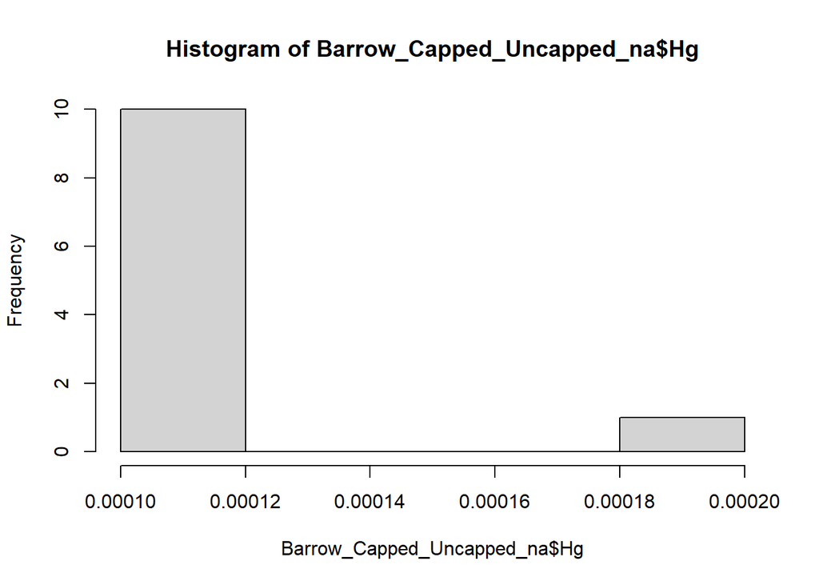

```r
hist(Barrow_Capped_Uncapped_na$Hg)
```

#Non-normal distribution

```r
HgWilcox <-wilcox.test(Barrow_Capped_Uncapped_na[,25] ~ Barrow_Capped_Uncapped_na[,1])
print(HgWilcox)
```

```
##
##  Wilcoxon rank sum test with continuity correction
##
## data:  Barrow_Capped_Uncapped_na[, 25] by Barrow_Capped_Uncapped_na[, 1]
## W = 16, p-value = 0.5708
## alternative hypothesis: true location shift is not equal to 0
```

#No significant differences.

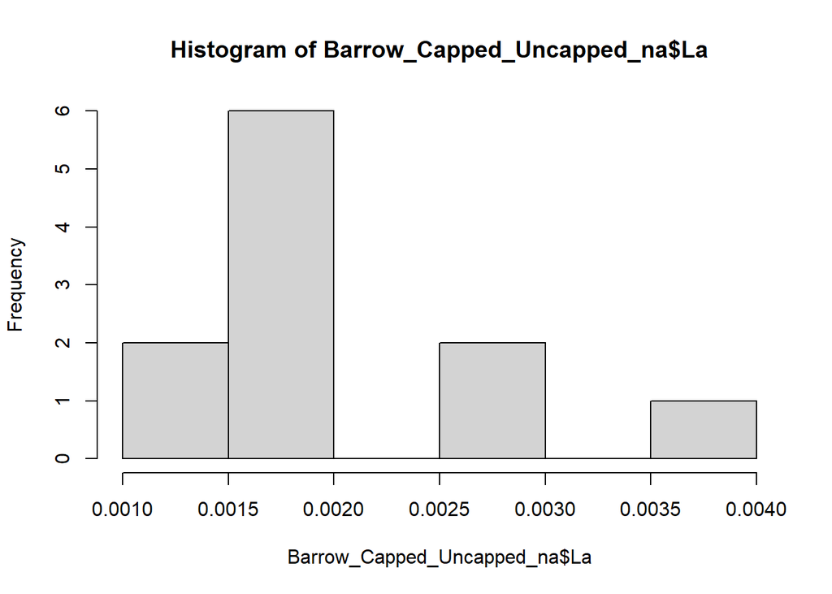

```r
hist(Barrow_Capped_Uncapped_na$La)
```

#Non-normal distribution

```r
LaWilcox <-wilcox.test(Barrow_Capped_Uncapped_na[,26] ~ Barrow_Capped_Uncapped_na[,1])
print(LaWilcox)
```

```
##
##  Wilcoxon rank sum test with continuity correction
##
## data:  Barrow_Capped_Uncapped_na[, 26] by Barrow_Capped_Uncapped_na[, 1]
## W = 2.5, p-value = 0.02265
## alternative hypothesis: true location shift is not equal to 0
```

#Will do a t-test for means.

```r
Capping_t_test_La <- t.test(Barrow_Capped_Uncapped_na[,26] ~ Barrow_Capped_Uncapped_na[,1])
print(Capping_t_test_La)
```

```
##
##  Welch Two Sample t-test
##
## data:  Barrow_Capped_Uncapped_na[, 26] by Barrow_Capped_Uncapped_na[, 1]
## t = -2.8701, df = 4.2607, p-value = 0.04219
## alternative hypothesis: true difference in means between group Capped and group Uncapped is not equal to 0
## 95 percent confidence interval:
##  -2.500041e-03 -7.138763e-05
## sample estimates:
##   mean in group Capped mean in group Uncapped
##            0.001714286            0.003000000
```

#La levels are significantly higher in uncapped substrates on the Barrow slag bank.

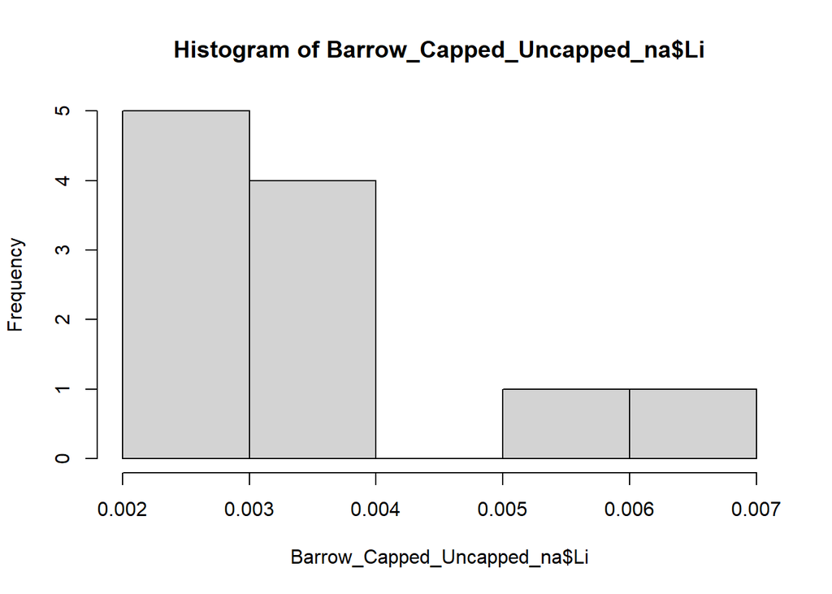

```r
hist(Barrow_Capped_Uncapped_na$Li)
```

#Non-normal distribution

```r
LiWilcox <-wilcox.test(Barrow_Capped_Uncapped_na[,27] ~ Barrow_Capped_Uncapped_na[,1])
print(LiWilcox)
```

```
##
##  Wilcoxon rank sum test with continuity correction
##
## data:  Barrow_Capped_Uncapped_na[, 27] by Barrow_Capped_Uncapped_na[, 1]
## W = 2, p-value = 0.02436
## alternative hypothesis: true location shift is not equal to 0
```

#T-test for means…

```r
Capping_t_test_Li <- t.test(Barrow_Capped_Uncapped_na[,27] ~ Barrow_Capped_Uncapped_na[,1])
print(Capping_t_test_Li)
```

```
##
##  Welch Two Sample t-test
##
## data:  Barrow_Capped_Uncapped_na[, 27] by Barrow_Capped_Uncapped_na[, 1]
## t = -2.7743, df = 4.0439, p-value = 0.0495
## alternative hypothesis: true difference in means between group Capped and group Uncapped is not equal to 0
## 95 percent confidence interval:
##  -4.492116e-03 -7.883676e-06
## sample estimates:
##   mean in group Capped mean in group Uncapped
##                0.00300                0.00525
```

#Li levels are significantly higher on uncapped parts of the Barrow slag bank.

#Skipping Mo because of similarities of values.

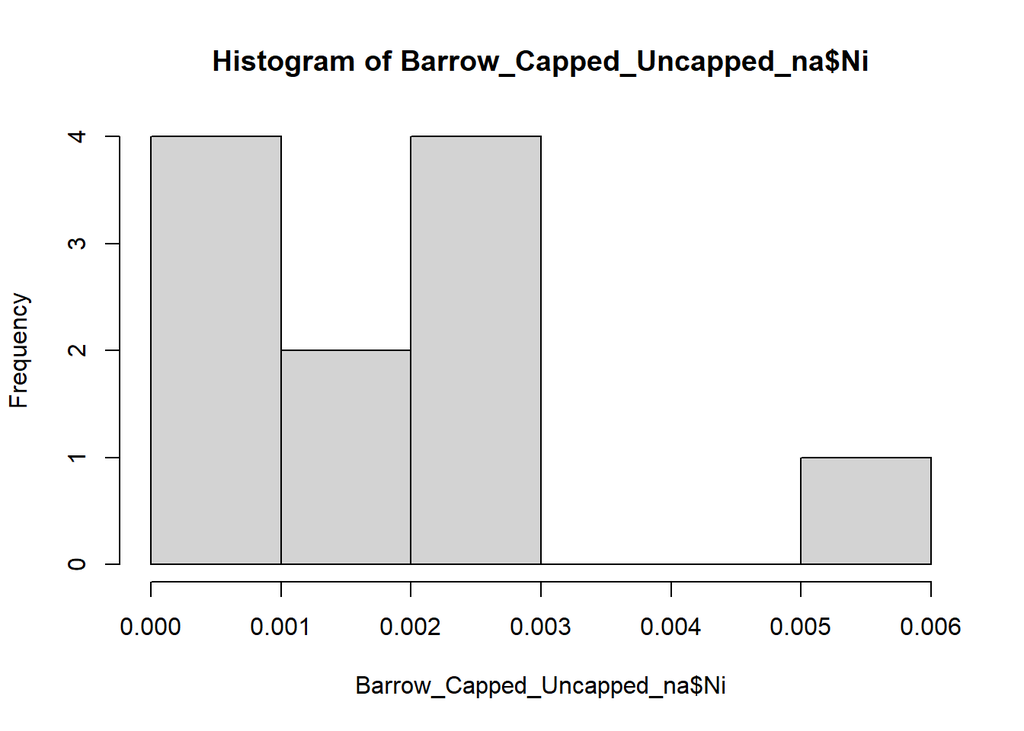

```r
hist(Barrow_Capped_Uncapped_na$Ni)
```

#Non-normal distribution

```r
NiWilcox <-wilcox.test(Barrow_Capped_Uncapped_na[,29] ~ Barrow_Capped_Uncapped_na[,1])
print(NiWilcox)
```

```
##
##  Wilcoxon rank sum test with continuity correction
##
## data:  Barrow_Capped_Uncapped_na[, 29] by Barrow_Capped_Uncapped_na[, 1]
## W = 28, p-value = 0.01038
## alternative hypothesis: true location shift is not equal to 0
```

#T test for means…

```r
Capping_t_test_Ni <- t.test(Barrow_Capped_Uncapped_na[,29] ~ Barrow_Capped_Uncapped_na[,1])
print(Capping_t_test_Ni)
```

```
##
##  Welch Two Sample t-test
##
## data:  Barrow_Capped_Uncapped_na[, 29] by Barrow_Capped_Uncapped_na[, 1]
## t = 3.9611, df = 6.775, p-value = 0.005825
## alternative hypothesis: true difference in means between group Capped and group Uncapped is not equal to 0
## 95 percent confidence interval:
##  0.0008892005 0.0035679424
## sample estimates:
##   mean in group Capped mean in group Uncapped
##            0.002828571            0.000600000
```

#Ni levels are significantly higher in capped substrates on the Barrow slag bank.

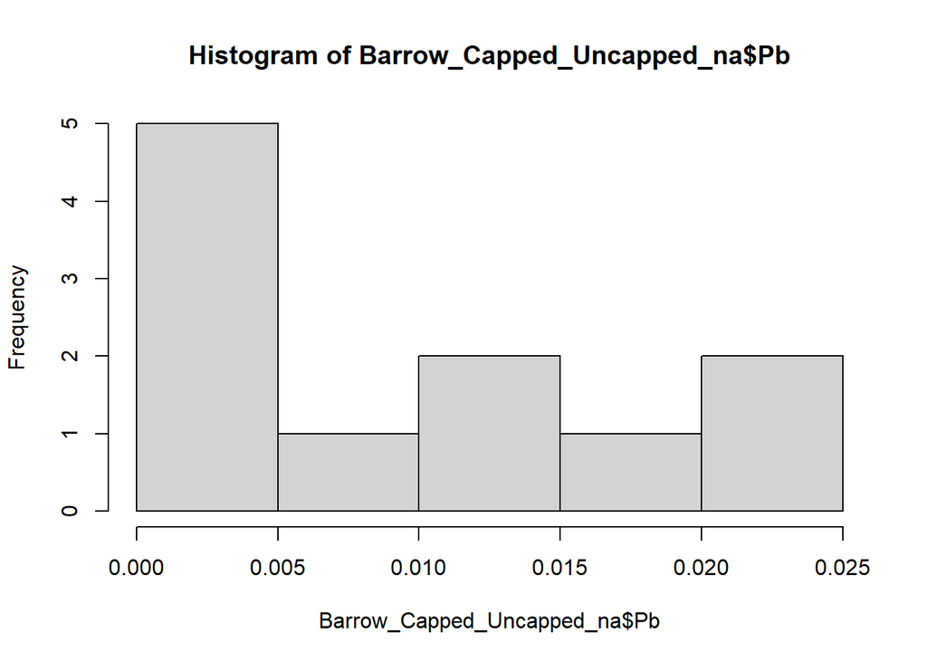

```r
hist(Barrow_Capped_Uncapped_na$Pb)
```

#Non-normal distribution.

```r
PbWilcox <-wilcox.test(Barrow_Capped_Uncapped_na[,30] ~ Barrow_Capped_Uncapped_na[,1])
print(PbWilcox)
```

```
##
##  Wilcoxon rank sum exact test
##
## data:  Barrow_Capped_Uncapped_na[, 30] by Barrow_Capped_Uncapped_na[, 1]
## W = 21, p-value = 0.2303
## alternative hypothesis: true location shift is not equal to 0
```

#T test for means…

```r
Capping_t_test_Pb <- t.test(Barrow_Capped_Uncapped_na[,30] ~ Barrow_Capped_Uncapped_na[,1])
print(Capping_t_test_Pb)
```

```
##
##  Welch Two Sample t-test
##
## data:  Barrow_Capped_Uncapped_na[, 30] by Barrow_Capped_Uncapped_na[, 1]
## t = 1.276, df = 7.6396, p-value = 0.2394
## alternative hypothesis: true difference in means between group Capped and group Uncapped is not equal to 0
## 95 percent confidence interval:
##  -0.004920796  0.016892225
## sample estimates:
##   mean in group Capped mean in group Uncapped
##             0.01158571             0.00560000
```

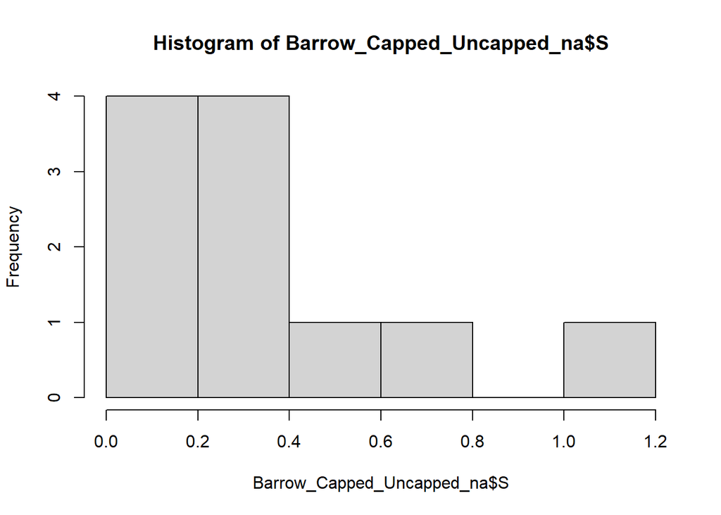

```r
hist(Barrow_Capped_Uncapped_na$S)
```

#Non-normal distribution

```r
SWilcox <-wilcox.test(Barrow_Capped_Uncapped_na[,31] ~ Barrow_Capped_Uncapped_na[,1])
print(SWilcox)
```

```
##
##  Wilcoxon rank sum test with continuity correction
##
## data:  Barrow_Capped_Uncapped_na[, 31] by Barrow_Capped_Uncapped_na[, 1]
## W = 1.5, p-value = 0.02303
## alternative hypothesis: true location shift is not equal to 0
```

#T test for means…

```r
Capping_t_test_S <- t.test(Barrow_Capped_Uncapped_na[,31] ~ Barrow_Capped_Uncapped_na[,1])
print(Capping_t_test_S)
```

```
##
##  Welch Two Sample t-test
##
## data:  Barrow_Capped_Uncapped_na[, 31] by Barrow_Capped_Uncapped_na[, 1]
## t = -2.5651, df = 3.2554, p-value = 0.07635
## alternative hypothesis: true difference in means between group Capped and group Uncapped is not equal to 0
## 95 percent confidence interval:
##  -1.11400362  0.09543219
## sample estimates:
##   mean in group Capped mean in group Uncapped
##              0.1657143              0.6750000
```

#S levels are significantly higher on the uncapped parts of the Barrow slag bank.

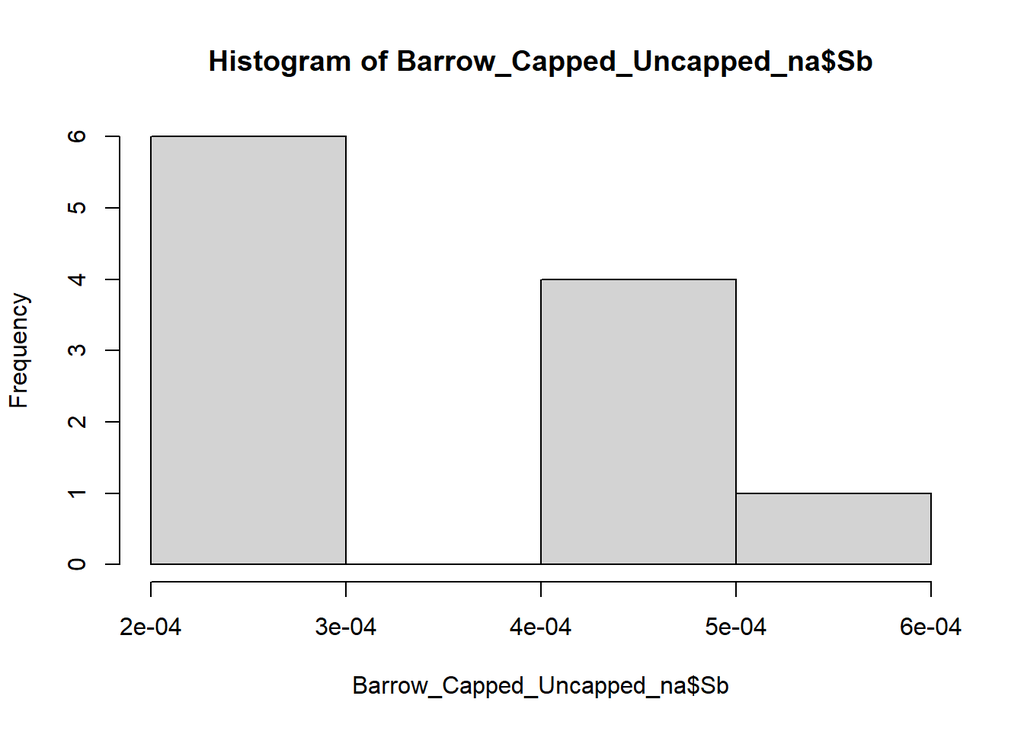

```r
hist(Barrow_Capped_Uncapped_na$Sb)
```

#Non-normal distribution

```r
SbWilcox <-wilcox.test(Barrow_Capped_Uncapped_na[,32] ~ Barrow_Capped_Uncapped_na[,1])
print(SbWilcox)
```

```
##
##  Wilcoxon rank sum test with continuity correction
##
## data:  Barrow_Capped_Uncapped_na[, 32] by Barrow_Capped_Uncapped_na[, 1]
## W = 22, p-value = 0.1362
## alternative hypothesis: true location shift is not equal to 0
```

#No significant differences

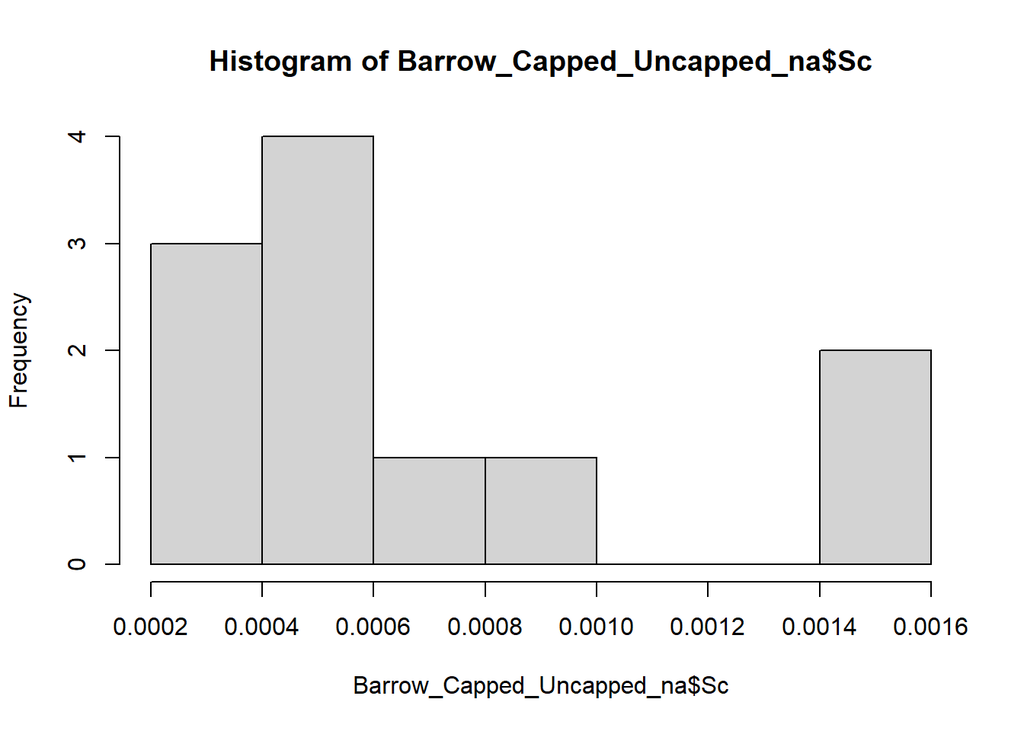

```r
hist(Barrow_Capped_Uncapped_na$Sc)
```

#Non-normal distribution

```r
ScWilcox <-wilcox.test(Barrow_Capped_Uncapped_na[,33] ~ Barrow_Capped_Uncapped_na[,1])
print(ScWilcox)
```

```
##
##  Wilcoxon rank sum test with continuity correction
##
## data:  Barrow_Capped_Uncapped_na[, 33] by Barrow_Capped_Uncapped_na[, 1]
## W = 5, p-value = 0.09853
## alternative hypothesis: true location shift is not equal to 0
```

#No significant differences

[output not shown]

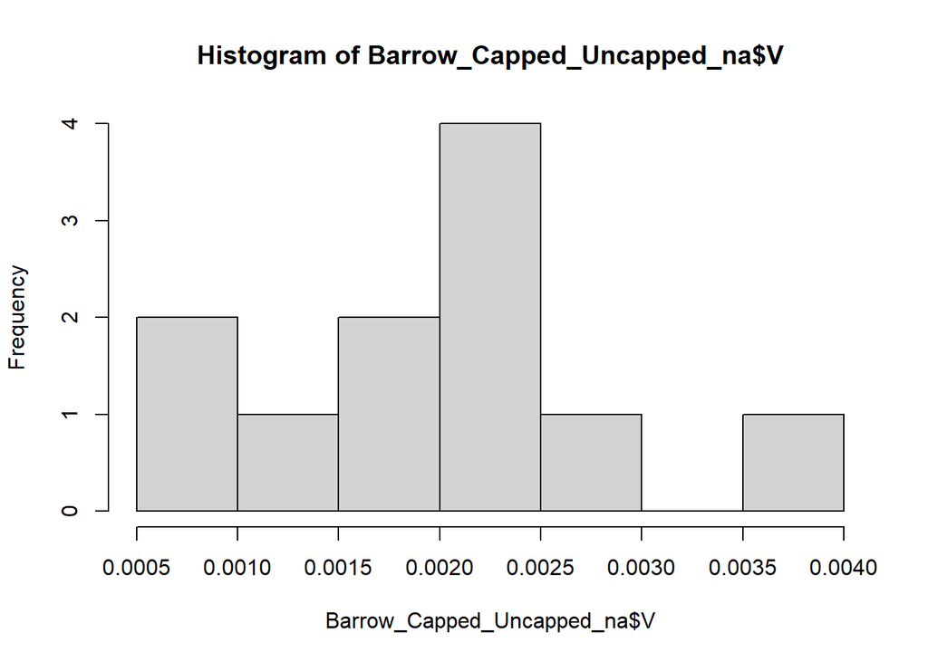

#Close to a normal distribution, will do a t test for this one…

```r
Capping_t_test_V <- t.test(Barrow_Capped_Uncapped_na[,38] ~ Barrow_Capped_Uncapped_na[,1])
print(Capping_t_test_V)
```

```
##
##  Welch Two Sample t-test
##
## data:  Barrow_Capped_Uncapped_na[, 38] by Barrow_Capped_Uncapped_na[, 1]
## t = 4.0081, df = 7.0068, p-value = 0.005127
## alternative hypothesis: true difference in means between group Capped and group Uncapped is not equal to 0
## 95 percent confidence interval:
##  0.0006166895 0.0023904533
## sample estimates:
##   mean in group Capped mean in group Uncapped
##            0.002528571            0.001025000
```

#V levels are significantly higher in capped parts of the Barrow slag bank.

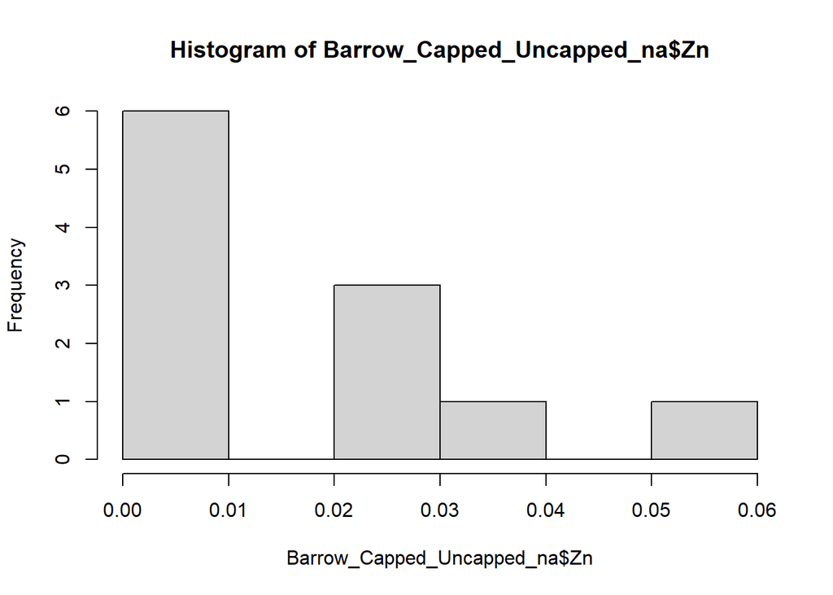

```r
hist(Barrow_Capped_Uncapped_na$Zn)
```

#Non-normal distribution

```r
ZnWilcox <-wilcox.test(Barrow_Capped_Uncapped_na[,40] ~ Barrow_Capped_Uncapped_na[,1])
print(ZnWilcox)
```

```
##
##  Wilcoxon rank sum exact test
##
## data:  Barrow_Capped_Uncapped_na[, 40] by Barrow_Capped_Uncapped_na[, 1]
## W = 24, p-value = 0.07273
## alternative hypothesis: true location shift is not equal to 0
```

#T test for means…

```r
Capping_t_test_Zn <- t.test(Barrow_Capped_Uncapped_na[,40] ~ Barrow_Capped_Uncapped_na[,1])
print(Capping_t_test_Zn)
```

```
##
##  Welch Two Sample t-test
##
## data:  Barrow_Capped_Uncapped_na[, 40] by Barrow_Capped_Uncapped_na[, 1]
## t = 1.7346, df = 8.8585, p-value = 0.1174
## alternative hypothesis: true difference in means between group Capped and group Uncapped is not equal to 0
## 95 percent confidence interval:
##  -0.004362586  0.032755443
## sample estimates:
##   mean in group Capped mean in group Uncapped
##             0.02247143             0.00827500
```